# Project4

Camille Cavicchio, Jared Steinberg, and Alain Perez

# Introduction

We are presenting three graphs taken from the `fec` SQL dataset, which has information on previous and current United States congressional officers. In `fec`, we use two data tables:

- **candidates -** a data table consisting of names, states, and identification numbers for candidates across the states.
- **contrib_com_to_cand -** information on amounts and types of monetary transactions donated to the candidates.**

With these data tables, we created the questions: *which state has the highest per capita donation, both for democrats and republicans? In these states, which individual has the most amount of money donated?* To go about this, we used the variables:

- **name -** name of the candidate
- **party -** democratic or republican
- **year -** year the candidate was running for office
- **transactions** number of transactions for each candidate
- **pop -** population of each state
- **proportion -** log of the sum of all individual transactions in a state per state population

To answer the first question, we use a combination of mapping packes (`maps`, `mapproj`, `ggmap`, `mapdata`, `USAboundaries`, `states`) to create two spatial maps of the United States, one democratic and one republican, illustrating a state-by-state visual comparison of congressional donations. We found that **Nevada** had the most contributions per capita for both republicans and democrats. Thus, to answer our second question, we created a bar graph of the individual candidates in Nevada to find that Republican Joe Heck had the highest proportion of donations relative to all other Nevadan candidates.

# Results

### Graph 1

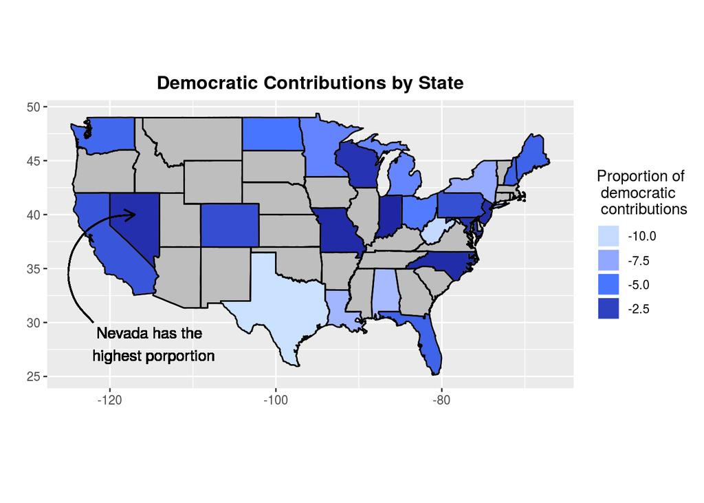

### Graph 2

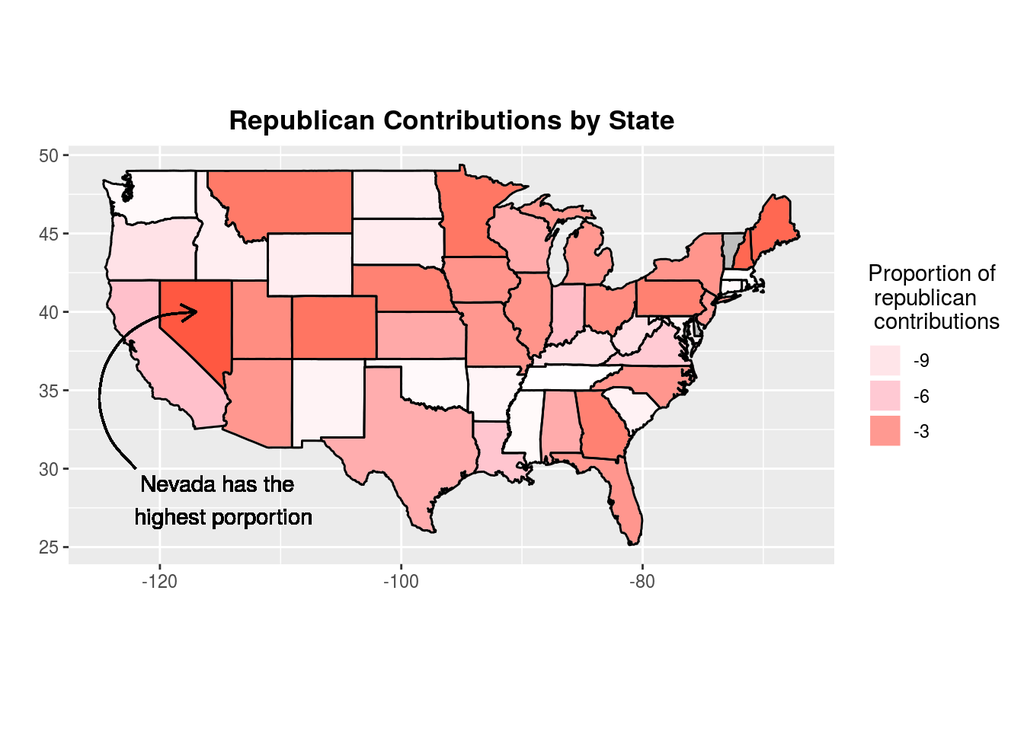

Similarly to the previous graph the graph above depicts the monetary contributions from constituents towards republican congressional candidates per state, and once again they are standardized by state per capita. Looking at the graph we can see that Nevada also has the highest per capita donations for Republic campaigns and Vermont - one of the most liberal states in the country is missing data so its colored grey.

### Body

The congressional elections are a major aspect of the United States government. In order to see how the donations for these campaigns were distributed amongst the different states and how they were distributed we needed to map out which states donated to which party’s congressional campaigns and how much relative to other states. The heat maps below offer a visual to how the donations were organized.

Interestingly enough, Nevada has the highest per capita contributions for both republican and democratic parties in the country. We wanted to evaluate the donations at a county level but that information isn’t in the data. Therefore, we decided to see the breakdown of the donations per congressional candidate in the Nevada in 2016, see Graph 3 below.

### Graph 3

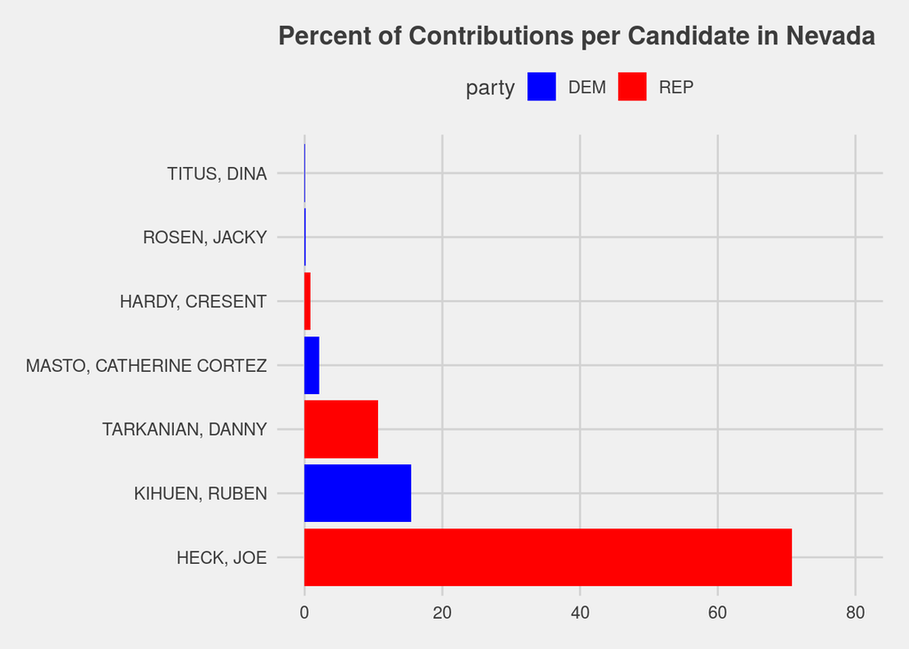

# Methodology

We looked at the `candidates` and `contrib_com_to_cand` datasets in order to have a dataset that gave us the contributions for each candidate running for congressional office. We limited this to the most recent elections. So 2016 and up, and then we limited again to only congressional elections. Once the dataset had been trimmed down we imported it into R . We uploaded a csv file that contained the population of each state in the U.S and wrangled it so that it had only the population of each state in 2016. We then joined our dataset with the csv dataset to created the `fecinfo` dataset, which we used to create the heat maps. In order to create the heat maps we split the fecinfo dataset into a republican data set and a democratic dataset by filtering ‘fecinfo’ for the appropriate party. We then summed up all the contributions per party per state and inputted these numbers into `maps`, `mapproj`, `ggmap`, `mapdata`, `USAboundaries`, and `states`. We decided to use different shades of red for the republican map because that is their party color, and we did the same for the democratic map. We decided to standardize the contributions by state population in order to facilitate our comparison to betweens states. Since Nevada was the state that had the highest per capita contributions we decided to see graph the contributions by country but that was not possible since the dataset lacked the appropriate zipcodes of the constituents that donated to the campaigns. The dataset does have the zipcodes of the receivers of the donations, but given that they all live in the same neighborhood that would have made for an interesting graph. Instead, we decided to graph the percent of Nevada’s contributions that each candidate received and we saw that representative Joe Heck had the highest percentage of the contributions by far.

# Conclusion

In summary, we started off looking at the `fec` dataset by looking at congressional donation patterns within the United States. We answered two questions: *which state has the highest per capita donation, both for democrats and republicans? In these states, which individual has the most amount of money donated?* We found that Nevada had the highest per capita donation for both democrats and republicans, and that in that state, representative Joe Heck had the highest percentage of contributions relative to other candidates. Overall, we are very pleased with our outcomes. However, at the start of the project, we had the idea of looking at county-wide contribution levels within states. This way, we could see which state had the highest proportion of contributions, and then in that state which county did the same. Unfortunately, we had to abandon this idea because the data reported the zip code of the recipient, not the actual donator, meaning that there was only one zip code per candidate. It was from here that we decided forego another spatial diagram and instead adopt a bar chart so we could still compare individual candidate contribution levels within Nevada. If we were to continue this project, we had the idea of finding the highest donated candidate in each state and then comparing all 50 of these people to find the highest paid candidate. Another thought was to see which candidates won their elections and compare this to who was paid the most. Unfortunately, we ran out of time to complete these projects, but it is clear to us that the `fec` dataset has a lot to offer and use.